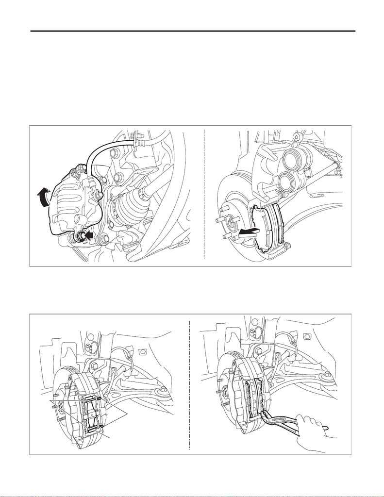

BR-17

Front Brake Pad

BRAKE

2. Front Brake Pad

A: REMOVAL

1. EXCEPT FOR STI MODEL

1) Lift up the vehicle, and then remove the front wheels.

2) Remove the pad - disc brake front.

(1) Remove the caliper bolt on the lower side.

(2) Raise the caliper body assembly and remove the pad - disc brake front.

NOTE:

Do not disconnect the brake hose from the caliper body assembly.

2. STI MODEL

1) Lift up the vehicle, and then remove the front wheels.

2) Remove the pad - disc brake front.

(1) Remove the clip - slide pin (a), and remove the pin - disc brake (b) and cross spring (c).

BR-01260

BR-01261

(a)

(c)

(b)

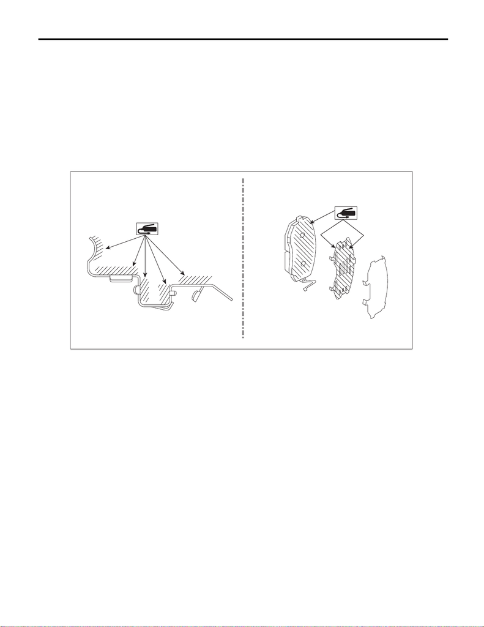

BR-18

Front Brake Pad

BRAKE

B: INSTALLATION

1. EXCEPT FOR STI MODEL

NOTE:

Before installation, remove mud and foreign matter from the caliper body assembly and support - front disc

brake.

1) Check the brake pad. <Ref. to BR-21, INSPECTION, Front Brake Pad.>

2) Apply a thin coat of grease to the pad clip, both sides of the shim - disc brake front inner and the shim

mounting surface of the pad - disc brake front.

Grease:

Pad clip (A): An item contained in the pad kit or equivalent

Shim and pad (B): An item contained in the pad kit or Molykote AS880N

BR-01262

(A) (B)

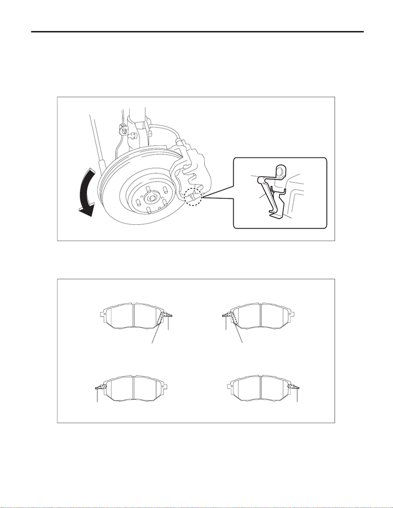

BR-19

Front Brake Pad

BRAKE

3) Install the pad - disc brake front.

CAUTION:

• Be sure to install so that the pad return spring faces the input side of the direction of disc rotor ro-

tation, as shown in the figure.

• Correctly install the pad return spring to the supporting surface of the pad clip as shown in the fig-

ure.

• If the pad return spring is deformed or damaged, replace the pad - disc brake front with a new part.

NOTE:

Install the pad indicator in proper direction.

(a) Pad return spring (b) Supporting surface of pad clip (c) Disc rotor rotation direction

(a) LH — IN (c) RH — IN (e) Pad indicator

(b) LH — OUT (d) RH — OUT (f) Pad return spring

BR-00920

(c)

(a)

(b)

BR-00867

(a)

(b)

(f)

(f)

(f)(f)

(c)

(e)

(e)

(d)

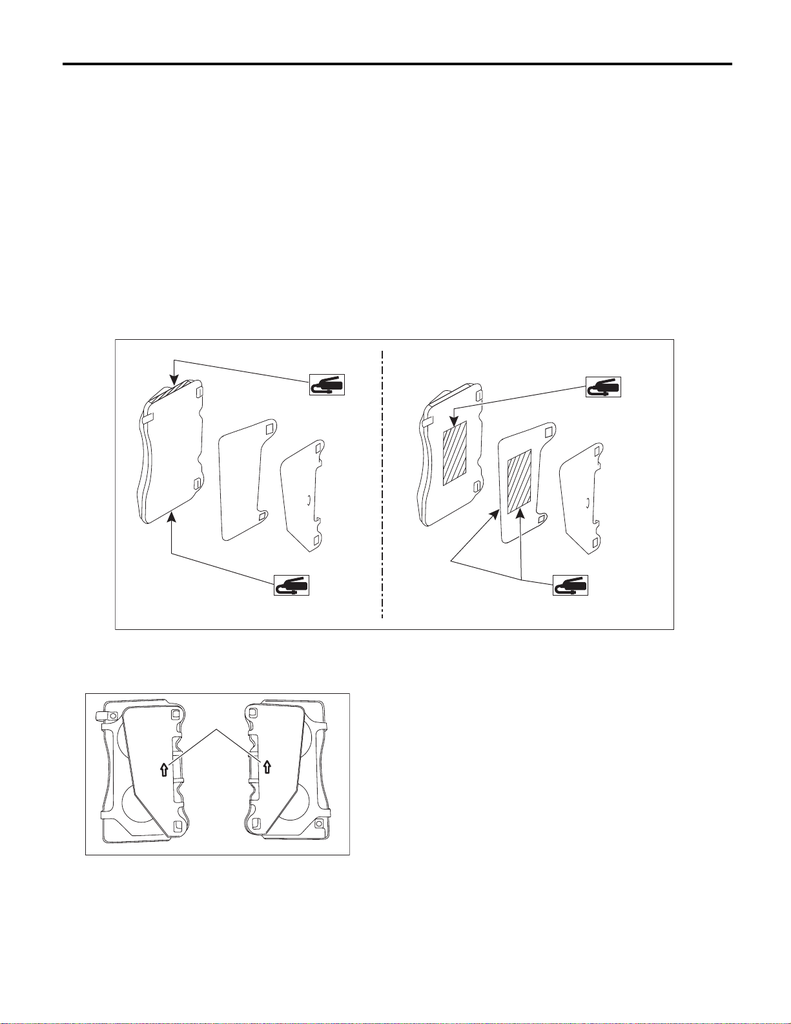

BR-20

Front Brake Pad

BRAKE

4) Install the caliper body assembly.

Tightening torque:

27 N·m (2.8 kgf-m, 19.9 ft-lb)

5) Install the front wheels.

Tightening torque:

120 N·m (12.2 kgf-m, 88.5 ft-lb)

2. STI MODEL

NOTE:

Before installation, remove mud and foreign matter from the disc brake assembly.

1) Apply a thin coat of grease to the side of the pad - disc brake front, both sides of the shim - disc brake front

inner and the shim mounting surface of the pad - disc brake front.

Grease:

Pad side (A): An item contained in the pad kit or equivalent

Shim and pad (B): An item contained in the pad kit or Molykote AS880N

2) Install the pad - disc brake front.

NOTE:

Install so that the arrow (a) faces upward.

3) Install the cross spring.

4) Install the pin - disc brake.

5) Install the clip - slide pin.

6) Install the front wheels.

Tightening torque:

120 N·m (12.2 kgf-m, 88.5 ft-lb)

BR-01263

(A) (B)

BR-01264

(a)

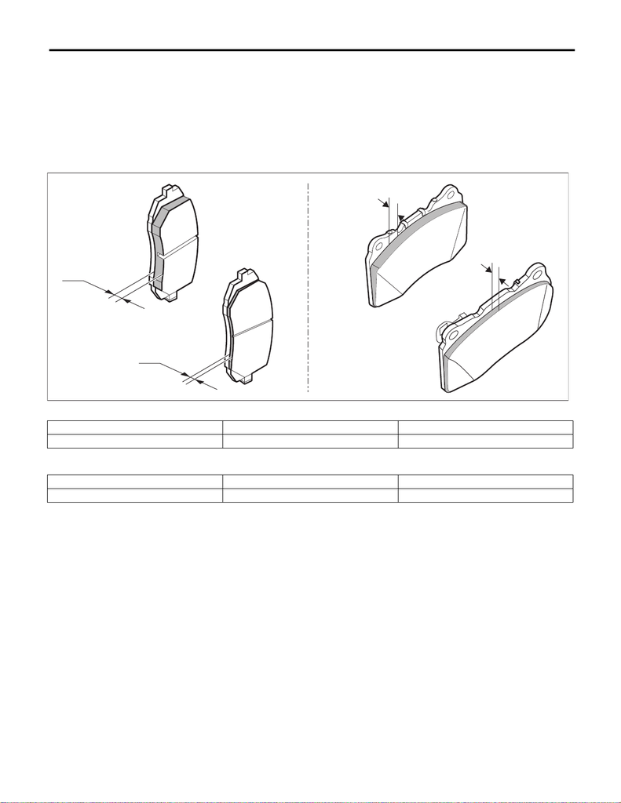

BR-21

Front Brake Pad

BRAKE

C: INSPECTION

1) Check the thickness (A) of the pad - disc brake front.

NOTE:

• Always replace the pads of both wheels and both sides as a set.

• Replace pad clips if they are twisted or worn.

• Replace the pad if there is oil or grease on it.

• Wear indicators are installed on the pad - disc brake front inner and the pad - disc brake front outer, and

a squeaking sound is heard if the pad is worn to the limit.

• Except for STI model

• STI model

2) If the wear limit is exceeded in the inspection, replace the pad - disc brake front.

Standard (A) Wear limit (B)

Pad thickness 11 mm (0.43 in) 1.5 mm (0.059 in)

Standard (a) Wear limit (b)

Pad thickness 8.9 mm (0.35 in) 1.2 mm (0.047 in)

BR-01265

(A)

(a)

(B)

(b)